# Philadelphia Eviction Judgments Prediction

MUSA 5080 Final Project

Annalise Abraham, Katie Knox, and Hope Levin

2025-12-08

# Policy Context

## Evictions are High in Philadelphia

- So far in 2025, there have been *11,166* eviction filings
- Over the past 12 months, the eviction filing rate has been *4%*

###### Source: The Eviction Lab at Princeton University

## Eviction Filing Rates (2024)

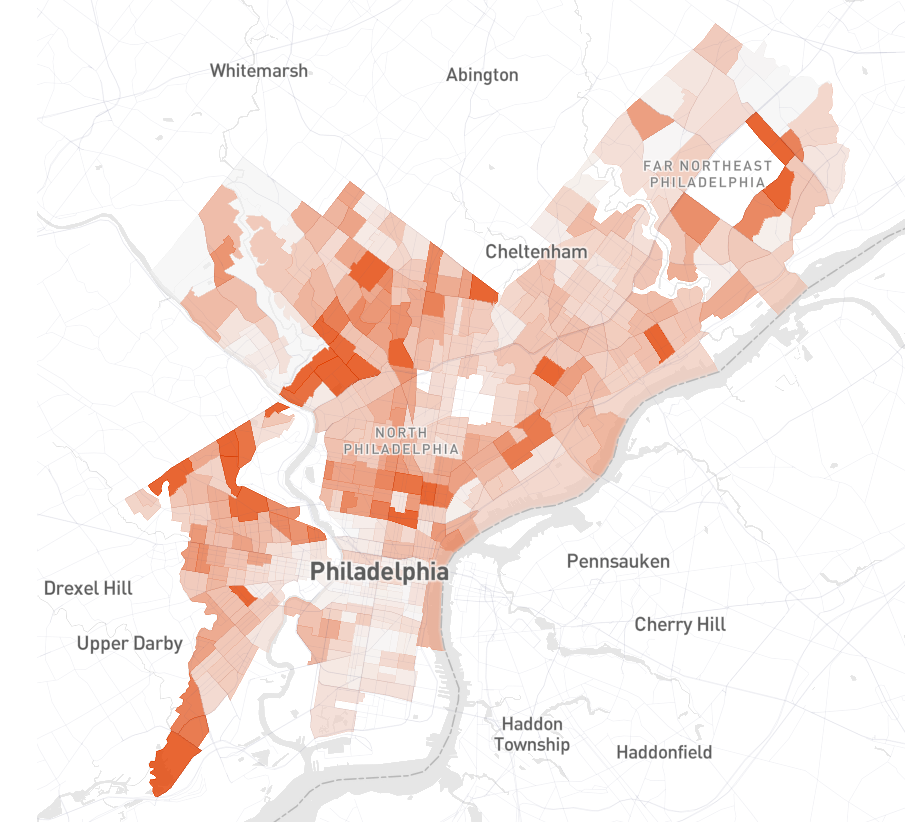

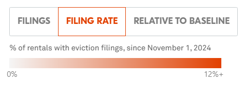

## The Eviction Process

- Filing - initial legal complaint a landlord submits to the Municipal Courts
- Judgement - final court order that legally evicts tenants
- Landlord files in Muncipal Court -> scheduled hearing -> court judgement
  - Many filings (about half in our dataset) are settled outside of court
  - Of the filings that proceed to a judgement, the vast majority end in the landlord’s favor

###### Source: The Eviction Lab at Princeton University

# Problem Statement

## Can We Predict the Number of Eviction Filings That Result in Judgments by Census Tract in Philadelphia?

- A higher likelihood of filings resulting in judgements indicates area where landlords are less willing to negotiate outside of court
- Tenants in these areas are more likely to experience unfavorable outcomes
- Thus, more resources and regulations should target those areas

## Related Questions

- What are the characteristics of census tracts with the high shares of judgements / filings?
- How can the city better protect tenants in those high risk areas?

# Data Sources

- Eviction Data: observed and validated eviction filings and judgments by Philadelphia Census Tract from the [Eviction Lab](https://data-downloads.evictionlab.org/#data-for-analysis/). Available years: 2010, 2011, 2012, and 2016
- Demographic Data: [American Community Survey](https://data.census.gov/table/ACSDP5Y2016.DP05?q=ACS+2016+philadelphia) (ACS) 2016 5-Year Estimates
- Property Data: Sales Records from 2023-2024 from the [Office of Property Assessment](https://opendataphilly.org/datasets/philadelphia-properties-and-assessment-history/)

# Our Model: Binomial Regression

## Given a Filing, what is the Probability of a Judgment?

- The outcome is binary: either the filing results in judgment or it does not

```r
binomial_group_model <- glm(cbind(judgments, filings - judgments) ~ category_code_description + median_year_built + total_livable_area + factor(year) + rent_burden_rate + median_h_incomeE + familiesE + black_percent + total_pop,
                         family = binomial,
                         data = model_data)
```

## Key Significant Variables

- *Dependent Variable* `(judgments, filings - judgments)`: weighs the probability of judgement by number of filings in census tract
- *Demographics*: rent burden, median household income, number of families, percent of Black residents, total population.
- *Housing Type*: most common property type per tract (category code), median year built, total livable area

## Cross Validation

- Train on 2010, 2011, 2012
- Test on 2016

# Results

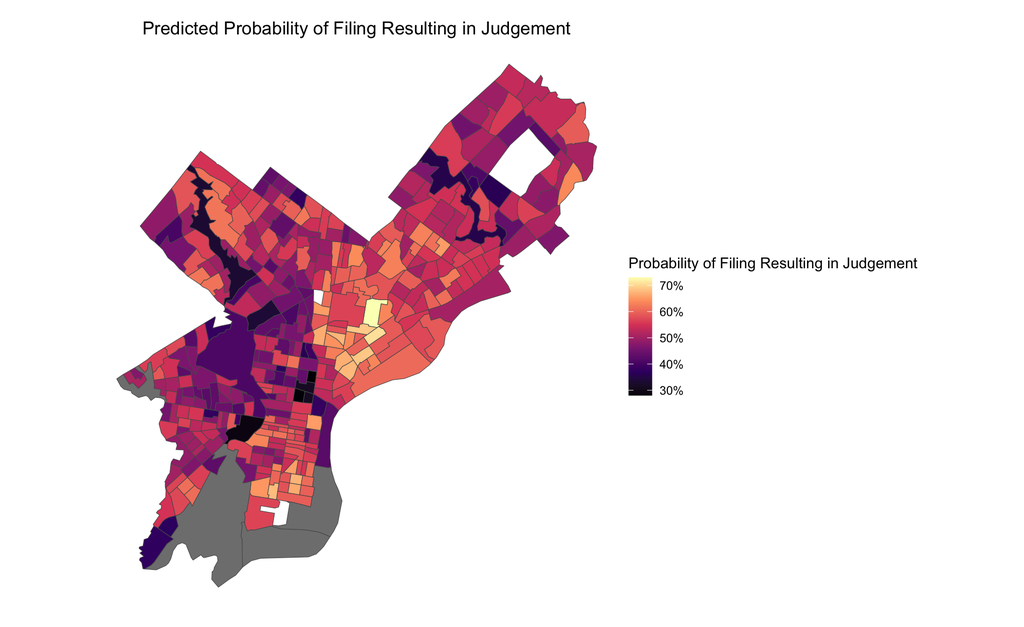

## Mean Absolute Error

- Convert probability into actual predicted judgements:

`test_data$predicted_judgments <- test_data$filings * test_data$predicted_prob_judgment`

- **MAE: 6.4**
- On average, we predict 6 judgements wrong based on the number of filings

## Map of Absolute Error

Errors are evenly distributed, with a few extreme outliers

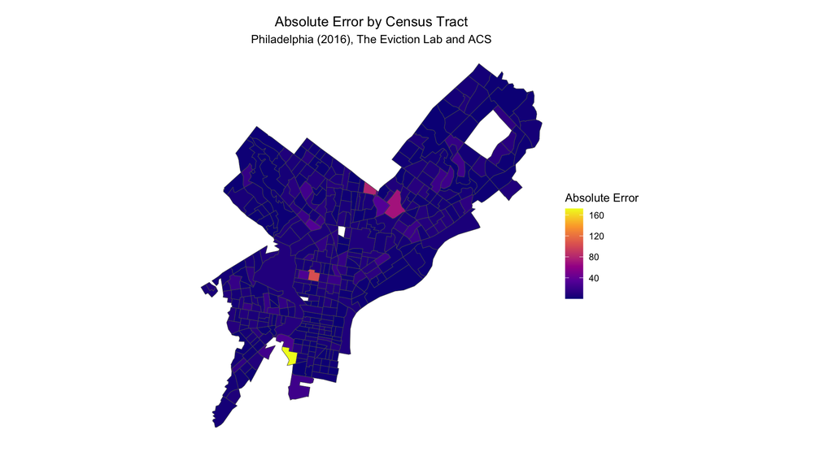

## 5 Highest Error Tracts (2016)

5 Highest Error Tracts (2016)

| Filings | Judgements | Judgements:Filings | Rent Burden | Median Household Income | Percent Black | Absolute Error |
| --- | --- | --- | --- | --- | --- | --- |
| 524 | 67 | 13% | 41% | 19k | 63% | 172 |
| 288 | 60 | 21% | 63% | 19k | 92% | 103 |
| 396 | 109 | 28% | 51% | 44k | 78% | 79 |
| 193 | 51 | 26% | 65% | 31k | 64% | 70 |
| 125 | 33 | 26% | 58% | 25k | 40% | 33 |

## Versus Overall Philadelphia (2016)

| Filings | Judgements | Judgements:Filings | Rent Burden | Median Household Income |
| --- | --- | --- | --- | --- |
| 21,769 | 10,234 | 47% | 51% | 11k - 145k |

- The highest-error tracts have much lower judgement rates (13-28%) compared to the city overall (47%)
- These tracts also tend to have lower median income and higher percentages of Black residents

# Limitations

- *Timeframe*: the data only covers 2010-2016. Since then, stronger renter protections may have changed eviction patterns.
- *Undocumented Evictions*: informal evictions and undocumented residents are not included, considering this data only examines court records
- *Data Gaps*: the Eviction Lab only provides filings and judgements for 2010, 2011, 2012, and 2016. Updated data is needed to reflect current times.

# Recommendations for Implementation

- Expand the “Good Cause” eviction protection for 1+ year leases
- Focus outreach programs and community engagement to tracts identified as high-risk by the model
- Investigate repeat eviction fillings and judgments to expose predatory landlords
- Institute affordable housing initiatives and better tenant protections to reduce structural eviction risk

# Full Data Citation

- Gromis, Ashley, Ian Fellows, James R. Hendrickson, Lavar Edmonds, Lillian Leung, Adam Porton, and Matthew Desmond. Estimating Eviction Prevalence across the United States. Princeton University Eviction Lab. https://data-downloads.evictionlab.org/#estimating-eviction-prevalance-across-us/. Deposited May 13, 2022.